# 07 Advanced Statistical Tests

17 April, 2018

## Overview

## Lesson Structure

In this session, we'll cover more advanced statistical tests, such as multifactorial experiments and experiments with factors of more than 2 levels.

Specifically, we'll cover:

- multilevel and multifactorial ANOVA
- multilevel and multiple regression
- factor coding (and why it matters in R)
- sum of squares (and why this matters in R)

## Getting Started

As always, we first need to load the `tidyverse` set of packages for this Chapter.

```r
library(tidyverse)
```

## Generate Data

### Numerical Stroop Data

```r
set.seed(1000)
stroop_dat <- tibble(
  subject = seq(1:60),
  congruent = rnorm(mean = 400, sd = 30, n = 60),
  incongruent = congruent + rnorm(mean = 60, sd = 10, n = 60),
  neutral = congruent + rnorm(mean = 30, sd = 10, n = 60)
  ) %>%
  gather(key = cond, value = reaction_time, 2:4) %>%
  mutate(
    cond = as.factor(cond),
    log_RT = log(reaction_time)
  )
```

## Generate Data

### Smoking Data

```r
# set parameters
set.seed(1000)
means <- rep(c(80, 80, 100), 100)
sds <- rep(c(5, 5, 7), 100)

# simulate data
cond <- rep(c("control", "drug_one", "drug_two"), 100)
subject <- seq(1:300)

smoking_dat <- tibble(
  subject = subject,
  cond = as.factor(cond),
  outcome = rnorm(n = 300, mean = means, sd = sds)
)
```

## Multilevel Linear Models

## Multilevel Linear Models

### Considering your Coding

We can ask different questions of our data, which we define by our contrast codes. This is particularly important when we have more than 1 factor in our model.

- Simple effect (e.g. several drugs against reference placebo): treatment coding
- Main effect (e.g. individual level against grand mean): sum/deviation coding

## Checking your Levels

Factor data allows us to do some cool things, like checking levels easily, or assigning contrast codes.

```r
levels(stroop_dat$cond)
```

```
## [1] "congruent"   "incongruent" "neutral"
```

```r
levels(smoking_dat$cond)
```

```
## [1] "control"  "drug_one" "drug_two"
```

*Note*: If your data isn't stored as a factor, use `as.factor()` or `factor()` on your variable.

## Contrast Matrices

```r
# make data 2 levels and convert condition to a factor
stroop_subset <- stroop_dat %>%
  filter(cond %in% c("congruent", "incongruent")) %>%
  mutate(cond = factor(cond))

# see your contrasts
contrasts(stroop_subset$cond)
```

```
##             incongruent
## congruent             0
## incongruent           1
```

## Fitting a Simple Model

```r
lm(log_RT ~ cond, stroop_subset) %>% summary()
```

```
##
## Call:
## lm(formula = log_RT ~ cond, data = stroop_subset)
##
## Residuals:
##      Min       1Q   Median       3Q      Max
## -0.15379 -0.04888  0.00581  0.03781  0.19539
##
## Coefficients:
##                 Estimate Std. Error t value Pr(>|t|)
## (Intercept)     5.978613   0.009196  650.14   <2e-16 ***
## condincongruent 0.145808   0.013005   11.21   <2e-16 ***
## ---
## Signif. codes:  0 '***' 0.001 '**' 0.01 '*' 0.05 '.' 0.1 ' ' 1
##
## Residual standard error: 0.07123 on 118 degrees of freedom
## Multiple R-squared:  0.5158, Adjusted R-squared:  0.5117
## F-statistic: 125.7 on 1 and 118 DF,  p-value: < 2.2e-16
```

Parameter estimates in main body of model, model fit below.

## Understanding the Simple Model

```r
stroop_subset %>%
  group_by(cond) %>%
  summarise(mean = mean(log_RT))
```

```
## # A tibble: 2 x 2
##   cond         mean
##   <fct>       <dbl>
## 1 congruent    5.98
## 2 incongruent  6.12
```

## Redefining your Contrasts

- `contrasts()` allows us to see how our data is represented. Redefine with the `contr.` family of functions.
- e.g. `contr.sum`, `contr.helmert`, `contr.poly`

```r
contrasts(stroop_subset$cond) <- contr.sum
contrasts(stroop_subset$cond)
```

```
##             [,1]
## congruent      1
## incongruent   -1
```

Now sums to 0, which is the intercept in any linear model. Hence, intercept is the mean across both levels.

## Modelling our Redefined Contrasts

```r
lm(log_RT ~ cond, stroop_subset) %>% summary()
```

```
##
## Call:
## lm(formula = log_RT ~ cond, data = stroop_subset)
##
## Residuals:
##      Min       1Q   Median       3Q      Max
## -0.15379 -0.04888  0.00581  0.03781  0.19539
##
## Coefficients:
##              Estimate Std. Error t value Pr(>|t|)
## (Intercept)  6.051517   0.006502  930.65   <2e-16 ***
## cond1       -0.072904   0.006502  -11.21   <2e-16 ***
## ---
## Signif. codes:  0 '***' 0.001 '**' 0.01 '*' 0.05 '.' 0.1 ' ' 1
##
## Residual standard error: 0.07123 on 118 degrees of freedom
## Multiple R-squared:  0.5158, Adjusted R-squared:  0.5117
## F-statistic: 125.7 on 1 and 118 DF,  p-value: < 2.2e-16
```

## Understanding our New Parameter Estimates

- Intercept is the grand mean
- condition (now labelled `cond1`; the first (and only) contrast in our contrast matrix for condition) is -0.073

```r
stroop_subset %>% summarise(mean = mean(log_RT))
```

```
## # A tibble: 1 x 1
##    mean
##   <dbl>
## 1  6.05
```

With only 2 levels, coding scheme doesn't affect interpretation of condition effect (only parameter estimates).

## Multilevel Regression

What happens if we have some more complex data? Let's look at the contrast matrix for the full Stroop data:

```r
contrasts(stroop_dat$cond)
```

```
##             incongruent neutral
## congruent             0       0
## incongruent           1       0
## neutral               0       1
```

- Congruent row sums to 0, hence it is the intercept. Others sum to 1.

## Multilevel Regression

```r
lm(log_RT ~ cond, data = stroop_dat) %>% summary
```

```
##
## Call:
## lm(formula = log_RT ~ cond, data = stroop_dat)
##
## Residuals:
##       Min        1Q    Median        3Q       Max
## -0.180561 -0.052211  0.002842  0.042382  0.195386
##
## Coefficients:
##                 Estimate Std. Error t value Pr(>|t|)
## (Intercept)     5.978613   0.009308 642.314  < 2e-16 ***
## condincongruent 0.145808   0.013163  11.077  < 2e-16 ***
## condneutral     0.073206   0.013163   5.561 9.74e-08 ***
## ---
## Signif. codes:  0 '***' 0.001 '**' 0.01 '*' 0.05 '.' 0.1 ' ' 1
##
## Residual standard error: 0.0721 on 177 degrees of freedom
## Multiple R-squared:  0.4094, Adjusted R-squared:  0.4027
## F-statistic: 61.35 on 2 and 177 DF,  p-value: < 2.2e-16
```

## Modelling our Multilevel Model

- Intercept = congruent condition
- incongruent condition (cond2) is the difference between the intercept mean and that incongruent level's mean.
- and neutral condition (cond3) is the difference between the intercept mean and that neutral level's mean

```r
stroop_dat %>% group_by(cond) %>% summarise(mean = mean(log_RT))
```

```
## # A tibble: 3 x 2
##   cond         mean
##   <fct>       <dbl>
## 1 congruent    5.98
## 2 incongruent  6.12
## 3 neutral      6.05
```

## Recoding our Multilevel Model

As before, we can ask for sum-coded effects. Now no row sums to 0, but all columns sum to 0.

```r
contrasts(stroop_dat$cond) <- contr.sum
contrasts(stroop_dat$cond)
```

```
##             [,1] [,2]
## congruent      1    0
## incongruent    0    1
## neutral       -1   -1
```

## Understanding our New Parameter Estimates

```r
lm(log_RT ~ cond, data = stroop_dat) %>% summary
```

```
##
## Call:
## lm(formula = log_RT ~ cond, data = stroop_dat)
##
## Residuals:
##       Min        1Q    Median        3Q       Max
## -0.180561 -0.052211  0.002842  0.042382  0.195386
##
## Coefficients:
##              Estimate Std. Error  t value Pr(>|t|)
## (Intercept)  6.051618   0.005374 1126.106   <2e-16 ***
## cond1       -0.073005   0.007600   -9.606   <2e-16 ***
## cond2        0.072803   0.007600    9.580   <2e-16 ***
## ---
## Signif. codes:  0 '***' 0.001 '**' 0.01 '*' 0.05 '.' 0.1 ' ' 1
##
## Residual standard error: 0.0721 on 177 degrees of freedom
## Multiple R-squared:  0.4094, Adjusted R-squared:  0.4027
## F-statistic: 61.35 on 2 and 177 DF,  p-value: < 2.2e-16
```

## Changing Intercept Orders

- Reset the data back to treatment coded effects.
- Make the condition variable a factor of itself, but specify your levels manually.
- First one in order is intercept (usually defaults to alphabetic order)

```r
contrasts(stroop_dat$cond) <- contr.treatment
stroop_dat$cond <- factor(stroop_dat$cond,
                          levels = c("neutral", "congruent", "incongruent")
                          )
```

## Changing Intercept Orders

```r
contrasts(stroop_dat$cond)
```

```
##             congruent incongruent
## neutral             0           0
## congruent           1           0
## incongruent         0           1
```

## Refitting with a New Reference

```r
lm(log_RT ~ cond, data = stroop_dat) %>% summary
```

```
##
## Call:
## lm(formula = log_RT ~ cond, data = stroop_dat)
##
## Residuals:
##       Min        1Q    Median        3Q       Max
## -0.180561 -0.052211  0.002842  0.042382  0.195386
##
## Coefficients:
##                  Estimate Std. Error t value Pr(>|t|)
## (Intercept)      6.051819   0.009308 650.179  < 2e-16 ***
## condcongruent   -0.073206   0.013163  -5.561 9.74e-08 ***
## condincongruent  0.072602   0.013163   5.515 1.22e-07 ***
## ---
## Signif. codes:  0 '***' 0.001 '**' 0.01 '*' 0.05 '.' 0.1 ' ' 1
##
## Residual standard error: 0.0721 on 177 degrees of freedom
## Multiple R-squared:  0.4094, Adjusted R-squared:  0.4027
## F-statistic: 61.35 on 2 and 177 DF,  p-value: < 2.2e-16
```

## Multilevel ANOVA

## Multilevel ANOVA

- `aov()` is just a wrapper around the `lm()` function
- this gives us main effects and interactions, rather than parameter estimates
- how does this work? they're both the general linear model!

```r
stroop_aov <- aov(log_RT ~ cond, data = stroop_dat)
summary(stroop_aov)
```

```
##              Df Sum Sq Mean Sq F value Pr(>F)
## cond          2 0.6378  0.3189   61.35 <2e-16 ***
## Residuals   177 0.9201  0.0052
## ---
## Signif. codes:  0 '***' 0.001 '**' 0.01 '*' 0.05 '.' 0.1 ' ' 1
```

…they're so similar, we can even ask for linear model results from our ANOVA model fit.

## Multilevel ANOVA

```r
summary.lm(stroop_aov)
```

```
##
## Call:
## aov(formula = log_RT ~ cond, data = stroop_dat)
##
## Residuals:
##       Min        1Q    Median        3Q       Max
## -0.180561 -0.052211  0.002842  0.042382  0.195386
##
## Coefficients:
##                  Estimate Std. Error t value Pr(>|t|)
## (Intercept)      6.051819   0.009308 650.179  < 2e-16 ***
## condcongruent   -0.073206   0.013163  -5.561 9.74e-08 ***
## condincongruent  0.072602   0.013163   5.515 1.22e-07 ***
## ---
## Signif. codes:  0 '***' 0.001 '**' 0.01 '*' 0.05 '.' 0.1 ' ' 1
##
## Residual standard error: 0.0721 on 177 degrees of freedom
## Multiple R-squared:  0.4094, Adjusted R-squared:  0.4027
## F-statistic: 61.35 on 2 and 177 DF,  p-value: < 2.2e-16
```

## Multiple Contrasts

- You may have notices treatment coding doesn't give us all contrasts
- i.e. we get A vs B, and A vs. C, but what about B vs. C?

## Multiple Contrasts

```r
smoking_lm <- lm(outcome ~ cond, data = smoking_dat)
summary(smoking_lm)
```

```
##
## Call:
## lm(formula = outcome ~ cond, data = smoking_dat)
##
## Residuals:
##      Min       1Q   Median       3Q      Max
## -15.7906  -3.1192   0.0561   3.1747  18.4927
##
## Coefficients:
##              Estimate Std. Error t value Pr(>|t|)
## (Intercept)   79.6866     0.5508 144.670   <2e-16 ***
## conddrug_one   0.7748     0.7790   0.995    0.321
## conddrug_two  20.5112     0.7790  26.331   <2e-16 ***
## ---
## Signif. codes:  0 '***' 0.001 '**' 0.01 '*' 0.05 '.' 0.1 ' ' 1
##
## Residual standard error: 5.508 on 297 degrees of freedom
## Multiple R-squared:   0.75,  Adjusted R-squared:  0.7483
## F-statistic: 445.4 on 2 and 297 DF,  p-value: < 2.2e-16
```

## Multiple Contrasts

2 options: (1) relevel factor, (2) calculate differences in original model fit. We'll do (1);

```r
smoking_dat$cond <- factor(smoking_dat$cond,
                           levels = c("drug_one", "drug_two", "control")
                           )
smoking_lm2 <- lm(outcome ~ cond, data = smoking_dat)
```

## Multiple Contrasts

```r
summary(smoking_lm2)
```

```
##
## Call:
## lm(formula = outcome ~ cond, data = smoking_dat)
##
## Residuals:
##      Min       1Q   Median       3Q      Max
## -15.7906  -3.1192   0.0561   3.1747  18.4927
##
## Coefficients:
##              Estimate Std. Error t value Pr(>|t|)
## (Intercept)   80.4614     0.5508 146.077   <2e-16 ***
## conddrug_two  19.7364     0.7790  25.337   <2e-16 ***
## condcontrol   -0.7748     0.7790  -0.995    0.321
## ---
## Signif. codes:  0 '***' 0.001 '**' 0.01 '*' 0.05 '.' 0.1 ' ' 1
##
## Residual standard error: 5.508 on 297 degrees of freedom
## Multiple R-squared:   0.75,  Adjusted R-squared:  0.7483
## F-statistic: 445.4 on 2 and 297 DF,  p-value: < 2.2e-16
```

## Multifactorial Analyses

## Multifactorial Analyses

### 3-level Factors

We'll use the inbuilt ToothGrowth data set, which looks at the effect of vitamin C on tooth growth in guinea pigs. This data set has 3 columns:

- len: tooth length
- supp: supplement type (vitamin C supplement or orange juice)
- dose: strength of dose (0.5, 1, 2)

## Load the Data

```r
# load the data
data("ToothGrowth")

# convert to tibble and make dose a factor
tooth <- ToothGrowth %>%
  mutate(dose = factor(dose)) %>%
  as.tibble()

# see the output
tooth
```

```
## # A tibble: 60 x 3
##      len supp  dose
##    <dbl> <fct> <fct>
##  1  4.20 VC    0.5
##  2 11.5  VC    0.5
##  3  7.30 VC    0.5
##  4  5.80 VC    0.5
##  5  6.40 VC    0.5
##  6 10.0  VC    0.5
##  7 11.2  VC    0.5
##  8 11.2  VC    0.5
##  9  5.20 VC    0.5
## 10  7.00 VC    0.5
## # ... with 50 more rows
```

## Multifactorial ANOVA

We want main effects and interactions. Check for more main effects by adding them to the formula like so:

`dependent variable ~ factor_one + factor_two`

To check for an interaction, we specify it like so:

`dependent variable ~ factor_one + factor_two + factor_one : factor_two`

Or, to save on typing, like so (these two are equivalent):

`dependent variable ~ factor_one * factor_two`

## Multifactorial ANOVA

We don't need to worry about contrast matrix for simple ANOVA output (but we do for unbalanced designs/model coefficients; more on the first point later).

Save the model fit as **tooth_aov** as we want to do some follow up tests later on.

```r
tooth_aov <- aov(len ~ supp * dose, data = tooth)
summary(tooth_aov)
```

```
##             Df Sum Sq Mean Sq F value   Pr(>F)
## supp         1  205.4   205.4  15.572 0.000231 ***
## dose         2 2426.4  1213.2  92.000  < 2e-16 ***
## supp:dose    2  108.3    54.2   4.107 0.021860 *
## Residuals   54  712.1    13.2
## ---
## Signif. codes:  0 '***' 0.001 '**' 0.01 '*' 0.05 '.' 0.1 ' ' 1
```

## Multifactorial ANOVA

Significant effect of all factors, check with plot.

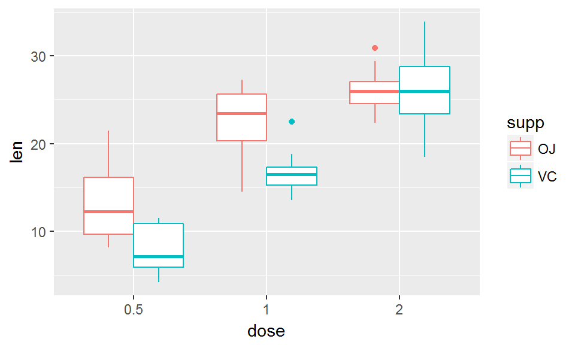

```r
ggplot(data = tooth, mapping = aes(x = dose, y = len, colour = supp)) +
  geom_boxplot()
```

## Multiple Comparisons

1 option: Tukey Honest Significant Difference: `TukeyHSD()` - Apply to our fitted model **tooth_aov** - Also have to specify the confidence level, which is by default 95%

```r
TukeyHSD(tooth_aov, conf.level = 0.95)
```

```
##   Tukey multiple comparisons of means
##     95% family-wise confidence level
##
## Fit: aov(formula = len ~ supp * dose, data = tooth)
##
## $supp
##       diff       lwr       upr     p adj
## VC-OJ -3.7 -5.579828 -1.820172 0.0002312
##
## $dose
##         diff       lwr       upr   p adj
## 1-0.5  9.130  6.362488 11.897512 0.0e+00
## 2-0.5 15.495 12.727488 18.262512 0.0e+00
## 2-1    6.365  3.597488  9.132512 2.7e-06
##
## $`supp:dose`
##                diff        lwr        upr     p adj
## VC:0.5-OJ:0.5 -5.25 -10.048124 -0.4518762 0.0242521
## OJ:1-OJ:0.5    9.47   4.671876 14.2681238 0.0000046
## VC:1-OJ:0.5    3.54  -1.258124  8.3381238 0.2640208
## OJ:2-OJ:0.5   12.83   8.031876 17.6281238 0.0000000
## VC:2-OJ:0.5   12.91   8.111876 17.7081238 0.0000000
## OJ:1-VC:0.5   14.72   9.921876 19.5181238 0.0000000
## VC:1-VC:0.5    8.79   3.991876 13.5881238 0.0000210
## OJ:2-VC:0.5   18.08  13.281876 22.8781238 0.0000000
## VC:2-VC:0.5   18.16  13.361876 22.9581238 0.0000000
## VC:1-OJ:1     -5.93 -10.728124 -1.1318762 0.0073930
## OJ:2-OJ:1      3.36  -1.438124  8.1581238 0.3187361
## VC:2-OJ:1      3.44  -1.358124  8.2381238 0.2936430
## OJ:2-VC:1      9.29   4.491876 14.0881238 0.0000069
## VC:2-VC:1      9.37   4.571876 14.1681238 0.0000058
## VC:2-OJ:2      0.08  -4.718124  4.8781238 1.0000000
```

## Multiple Comparisons (So Much Output!)

You can cut down on the output by asking for just the interaction terms:

```r
tukey_aov <- TukeyHSD(tooth_aov, conf.level = 0.95)
tukey_aov$`supp:dose`
```

```
##                diff        lwr        upr        p adj
## VC:0.5-OJ:0.5 -5.25 -10.048124 -0.4518762 2.425209e-02
## OJ:1-OJ:0.5    9.47   4.671876 14.2681238 4.612304e-06
## VC:1-OJ:0.5    3.54  -1.258124  8.3381238 2.640208e-01
## OJ:2-OJ:0.5   12.83   8.031876 17.6281238 2.125153e-09
## VC:2-OJ:0.5   12.91   8.111876 17.7081238 1.769939e-09
## OJ:1-VC:0.5   14.72   9.921876 19.5181238 2.985967e-11
## VC:1-VC:0.5    8.79   3.991876 13.5881238 2.100948e-05
## OJ:2-VC:0.5   18.08  13.281876 22.8781238 4.855005e-13
## VC:2-VC:0.5   18.16  13.361876 22.9581238 4.821699e-13
## VC:1-OJ:1     -5.93 -10.728124 -1.1318762 7.393032e-03
## OJ:2-OJ:1      3.36  -1.438124  8.1581238 3.187361e-01
## VC:2-OJ:1      3.44  -1.358124  8.2381238 2.936430e-01
## OJ:2-VC:1      9.29   4.491876 14.0881238 6.908163e-06
## VC:2-VC:1      9.37   4.571876 14.1681238 5.774013e-06
## VC:2-OJ:2      0.08  -4.718124  4.8781238 1.000000e+00
```

## Multiple Regression

## Multiple Regression

- A little more complex if you want parameter estimates. Easiest to use `aov()`
- Still, can assess main effects by improvement to model fit
- Need to set up contrast codes manually, then…
- compare models with and without the coded factors included

```r
# code new centered variables
tooth$supp_dev <- (tooth$supp == "VC") - mean(tooth$supp == "VC")
tooth$dose_dev_one <- (tooth$dose == "0.5") - mean(tooth$dose == "0.5")
tooth$dose_dev_two <- (tooth$dose == "1") - mean(tooth$dose == "1")
```

## Multiple Regression

```r
tooth # inspect changes
```

```
## # A tibble: 60 x 6
##      len supp  dose  supp_dev dose_dev_one dose_dev_two
##    <dbl> <fct> <fct>    <dbl>        <dbl>        <dbl>
##  1  4.20 VC    0.5      0.500        0.667       -0.333
##  2 11.5  VC    0.5      0.500        0.667       -0.333
##  3  7.30 VC    0.5      0.500        0.667       -0.333
##  4  5.80 VC    0.5      0.500        0.667       -0.333
##  5  6.40 VC    0.5      0.500        0.667       -0.333
##  6 10.0  VC    0.5      0.500        0.667       -0.333
##  7 11.2  VC    0.5      0.500        0.667       -0.333
##  8 11.2  VC    0.5      0.500        0.667       -0.333
##  9  5.20 VC    0.5      0.500        0.667       -0.333
## 10  7.00 VC    0.5      0.500        0.667       -0.333
## # ... with 50 more rows
```

## Model Comparisons

Fit a full model with both factors (notice parentheses)

```r
tooth_lm_full <- lm(len ~ supp_dev * (dose_dev_one + dose_dev_two), data = tooth)
```

## Model Comparisons

Next, we construct a reduced model, and use the `anova()` function to compare the two models against one another. Does the interaction improve our model?

```r
tooth_lm_reduced <- lm(len ~ supp_dev + (dose_dev_one + dose_dev_two), data = tooth)
anova(tooth_lm_full, tooth_lm_reduced)
```

```
## Analysis of Variance Table
##
## Model 1: len ~ supp_dev * (dose_dev_one + dose_dev_two)
## Model 2: len ~ supp_dev + (dose_dev_one + dose_dev_two)
##   Res.Df    RSS Df Sum of Sq     F  Pr(>F)
## 1     54 712.11
## 2     56 820.43 -2   -108.32 4.107 0.02186 *
## ---
## Signif. codes:  0 '***' 0.001 '**' 0.01 '*' 0.05 '.' 0.1 ' ' 1
```

## Exploring Interactions

- One way is to run multiple t-tests, adjusting *p*-value for inflation
- Need a column which makes combinations of factor levels
- Make this with `interaction()`

```r
# create combined factor column
tooth$interact <- interaction(tooth$supp, tooth$dose)

# check levels of our new factor
levels(tooth$interact)
```

```
## [1] "OJ.0.5" "VC.0.5" "OJ.1"   "VC.1"   "OJ.2"   "VC.2"
```

## Exploring Interactions

- Conduct pairwise *t*-tests with `pairwise.t.test()`
- If you want more information, just fit models on subsets of your data and adjust your *p*-value accordingly

```r
pairwise.t.test(tooth$len, tooth$interact)
```

```
##
##  Pairwise comparisons using t tests with pooled SD
##
## data:  tooth$len and tooth$interact
##
##        OJ.0.5  VC.0.5  OJ.1   VC.1    OJ.2
## VC.0.5 0.0105  -       -      -       -
## OJ.1   3.2e-06 2.6e-11 -      -       -
## VC.1   0.1346  1.0e-05 0.0035 -       -
## OJ.2   1.6e-09 1.9e-14 0.1346 3.8e-06 -
## VC.2   1.4e-09 1.7e-14 0.1346 3.6e-06 0.9609
##
## P value adjustment method: holm
```

## Multifactorial Analyses

### 2-level Factors

- Easier than 3 level factors, as centred variables are easy to interpret
- Simply ask, what is the effect of this variable on the mean?
- One condition is assigned negative sign, the other positive (e.g. -1/1)
- Direction of effect (i.e. +/- sign) indicates condition effect

## Make Data

Let's just look at the 0.5 and 1 doses. Imagine this was the original data set.

```r
tooth_sub <- tooth %>%
  dplyr::select(1 : 3) %>%
  filter(dose %in% c(0.5, 1)) %>%
  mutate(dose = factor(dose))
tooth_sub # look at the data
```

```
## # A tibble: 40 x 3
##      len supp  dose
##    <dbl> <fct> <fct>
##  1  4.20 VC    0.5
##  2 11.5  VC    0.5
##  3  7.30 VC    0.5
##  4  5.80 VC    0.5
##  5  6.40 VC    0.5
##  6 10.0  VC    0.5
##  7 11.2  VC    0.5
##  8 11.2  VC    0.5
##  9  5.20 VC    0.5
## 10  7.00 VC    0.5
## # ... with 30 more rows
```

## Fit Model

### Main Effects

As always, set your coding for main effects:

```r
contrasts(tooth_sub$supp) <- contr.sum
contrasts(tooth_sub$dose) <- contr.sum
```

Then we can fit the model again.

```r
tooth_sub_lm <- lm(len ~ supp * dose, data = tooth_sub)
```

## Fit Model

### Main Effects

See the model output.

```r
summary(tooth_sub_lm)
```

```
##
## Call:
## lm(formula = len ~ supp * dose, data = tooth_sub)
##
## Residuals:
##    Min     1Q Median     3Q    Max
##  -8.20  -2.72  -0.27   2.65   8.27
##
## Coefficients:
##             Estimate Std. Error t value Pr(>|t|)
## (Intercept)  15.1700     0.5537  27.397  < 2e-16 ***
## supp1         2.7950     0.5537   5.048 1.30e-05 ***
## dose1        -4.5650     0.5537  -8.244 8.25e-10 ***
## supp1:dose1  -0.1700     0.5537  -0.307    0.761
## ---
## Signif. codes:  0 '***' 0.001 '**' 0.01 '*' 0.05 '.' 0.1 ' ' 1
##
## Residual standard error: 3.502 on 36 degrees of freedom
## Multiple R-squared:  0.7221, Adjusted R-squared:  0.6989
## F-statistic: 31.18 on 3 and 36 DF,  p-value: 4.098e-10
```

## Fit Model

### Simple Effects

```r
contrasts(tooth_sub$supp) <- contr.treatment
contrasts(tooth_sub$supp)
```

```
##    2
## OJ 0
## VC 1
```

- OJ will now be our reference value for the intercept
- dose will be compared at this intercept value, so we now have simple effects of dose, and main effects of supplement
- interaction term remains the same regardless of our coding approach

## Fit Model

### Simple Effects

```r
tooth_sub_lm2 <- lm(len ~ supp * dose, data = tooth_sub)
summary(tooth_sub_lm2)
```

```
##
## Call:
## lm(formula = len ~ supp * dose, data = tooth_sub)
##
## Residuals:
##    Min     1Q Median     3Q    Max
##  -8.20  -2.72  -0.27   2.65   8.27
##
## Coefficients:
##             Estimate Std. Error t value Pr(>|t|)
## (Intercept)  17.9650     0.7831  22.942  < 2e-16 ***
## supp2        -5.5900     1.1074  -5.048 1.30e-05 ***
## dose1        -4.7350     0.7831  -6.047 6.02e-07 ***
## supp2:dose1   0.3400     1.1074   0.307    0.761
## ---
## Signif. codes:  0 '***' 0.001 '**' 0.01 '*' 0.05 '.' 0.1 ' ' 1
##
## Residual standard error: 3.502 on 36 degrees of freedom
## Multiple R-squared:  0.7221, Adjusted R-squared:  0.6989
## F-statistic: 31.18 on 3 and 36 DF,  p-value: 4.098e-10
```

## Mixed Analyses

- Simulate smoking data (just copy and paste this code)

```r
set.seed(1000)
means <- rep(c(80, 85), 100)
sds <- rep(c(5, 5, 7), 100)
cond <- rep(c("control", "drug_one"), 100)
subject <- seq(1:200)
smoking_dat_extra <- tibble(
  subject = subject,
  cond = as.factor(cond),
  time_one = rnorm(n = 200, mean = means, sd = sds),
  time_two = time_one + rnorm(n = 200, mean = 5, sd = sds)
  ) %>%
  gather(key = test_time, value = recovery, 3:4) %>%
  mutate(test_time = as.factor(test_time)) %>%
  arrange(subject)
```

## Mixed Analyses

- Make smoking data (just copy and paste this code)

```r
# view the data
smoking_dat_extra
```

```
## # A tibble: 400 x 4
##    subject cond     test_time recovery
##      <int> <fct>    <fct>        <dbl>
##  1       1 control  time_one      77.8
##  2       1 control  time_two      87.4
##  3       2 drug_one time_one      79.0
##  4       2 drug_one time_two      87.6
##  5       3 control  time_one      80.3
##  6       3 control  time_two      73.5
##  7       4 drug_one time_one      88.2
##  8       4 drug_one time_two      92.0
##  9       5 control  time_one      76.1
## 10       5 control  time_two      77.8
## # ... with 390 more rows
```

## Mixed Linear Models

Set contrasts…

```r
contrasts(smoking_dat_extra$cond) <- contr.sum
contrasts(smoking_dat_extra$test_time) <- contr.sum
```

then, refit the model as before:

```r
mixed_lm <- lm(recovery ~ cond * test_time, data = smoking_dat_extra)
```

## Mixed Linear Models

```r
summary(mixed_lm) # see model output
```

```
##
## Call:
## lm(formula = recovery ~ cond * test_time, data = smoking_dat_extra)
##
## Residuals:
##      Min       1Q   Median       3Q      Max
## -23.7613  -3.8794   0.4193   4.3061  20.2756
##
## Coefficients:
##                  Estimate Std. Error t value Pr(>|t|)
## (Intercept)       85.3816     0.3370 253.385  < 2e-16 ***
## cond1             -2.6232     0.3370  -7.785 6.15e-14 ***
## test_time1        -2.5064     0.3370  -7.438 6.40e-13 ***
## cond1:test_time1   0.0612     0.3370   0.182    0.856
## ---
## Signif. codes:  0 '***' 0.001 '**' 0.01 '*' 0.05 '.' 0.1 ' ' 1
##
## Residual standard error: 6.739 on 396 degrees of freedom
## Multiple R-squared:  0.2265, Adjusted R-squared:  0.2206
## F-statistic: 38.65 on 3 and 396 DF,  p-value: < 2.2e-16
```

## Mixed Linear Models

**Problem**: `lm()` doesn't account for subject-variability. Can't account for within-subjects design here.

Fix by using: - `aov()` function with error terms (as in previous lessons – remember this is just a wrapper for `lm()`) - **linear mixed effects models** with random effects by participant (future lessons)

## Mixed ANOVA

Simply define error term as test time within subjects for within-subjects effect only.

```r
mixed_aov <- aov(recovery ~ cond * test_time +
                   Error(subject/test_time),
                 data = smoking_dat_extra)
```

## Mixed ANOVA

```r
summary(mixed_aov) # see model output
```

```
##
## Error: subject
##      Df Sum Sq Mean Sq
## cond  1  261.2   261.2
##
## Error: subject:test_time
##           Df Sum Sq Mean Sq
## test_time  1   2077    2077
##
## Error: Within
##                 Df Sum Sq Mean Sq F value   Pr(>F)
## cond             1   2738  2738.1  60.877 5.51e-14 ***
## test_time        1    454   453.9  10.091  0.00161 **
## cond:test_time   1      1     1.4   0.031  0.85956
## Residuals      394  17721    45.0
## ---
## Signif. codes:  0 '***' 0.001 '**' 0.01 '*' 0.05 '.' 0.1 ' ' 1
```

## A Note on Sum of Squares

For unbalanced designs, how the sum of squares is calculated has a big effect on interpretations

- **type-I** = R's default, order matters, determine variance by first term in model, then second etc. First thus gets most variance.
- **type-II** = main effects get variance, not interactions. Contrast coding doesn't matter.
- **type-III** = SPSS's default. Determines variance for all factors including interaction together. Needs orthogonal contrast codes (e.g. `contr.sum`)

## A Note on Sum of Squares

Make some unbalanced data from the **tooth_sub** data.

```r
tooth_sub_unbalanced <- tooth_sub[2:40,]
head(tooth_sub_unbalanced) # see the data
```

```
## # A tibble: 6 x 3
##     len supp  dose
##   <dbl> <fct> <fct>
## 1 11.5  VC    0.5
## 2  7.30 VC    0.5
## 3  5.80 VC    0.5
## 4  6.40 VC    0.5
## 5 10.0  VC    0.5
## 6 11.2  VC    0.5
```

## A Note on Sum of Squares

Fit with **supp** first:

```r
supp_first <- aov(len ~ supp * dose, data = tooth_sub_unbalanced)
summary(supp_first)
```

```
##             Df Sum Sq Mean Sq F value   Pr(>F)
## supp         1  259.4   259.4  21.331 5.05e-05 ***
## dose         1  777.3   777.3  63.920 2.09e-09 ***
## supp:dose    1    2.9     2.9   0.242    0.626
## Residuals   35  425.6    12.2
## ---
## Signif. codes:  0 '***' 0.001 '**' 0.01 '*' 0.05 '.' 0.1 ' ' 1
```

## A Note on Sum of Squares

Fit with **dose** first:

```r
dose_first <- aov(len ~ dose * supp, data = tooth_sub_unbalanced)
summary(dose_first)
```

```
##             Df Sum Sq Mean Sq F value   Pr(>F)
## dose         1  753.3   753.3  61.948 2.98e-09 ***
## supp         1  283.4   283.4  23.304 2.70e-05 ***
## dose:supp    1    2.9     2.9   0.242    0.626
## Residuals   35  425.6    12.2
## ---
## Signif. codes:  0 '***' 0.001 '**' 0.01 '*' 0.05 '.' 0.1 ' ' 1
```

## A Note on Sum of Squares

Use the `Anova()` function from the **car** package (capital A in `Anova()`!) - Defaults to type-II sum of squares, so ask for type-III!

```r
# install.packages("car") # install once per machine
library(car) # load each time you open R
```

## A Note on Sum of Squares

- Equivalent results with type-III sum of squares:

```r
Anova(supp_first, type = "III")
```

```
## Anova Table (Type III tests)
##
## Response: len
##             Sum Sq Df F value    Pr(>F)
## (Intercept) 6454.8  1 530.797 < 2.2e-16 ***
## supp         281.6  1  23.158 2.824e-05 ***
## dose         448.4  1  36.873 6.201e-07 ***
## supp:dose      2.9  1   0.242    0.6258
## Residuals    425.6 35
## ---
## Signif. codes:  0 '***' 0.001 '**' 0.01 '*' 0.05 '.' 0.1 ' ' 1
```

## A Note on Sum of Squares

- Equivalent results with type-III sum of squares:

```r
Anova(dose_first, type = "III")
```

```
## Anova Table (Type III tests)
##
## Response: len
##             Sum Sq Df F value    Pr(>F)
## (Intercept) 6454.8  1 530.797 < 2.2e-16 ***
## dose         448.4  1  36.873 6.201e-07 ***
## supp         281.6  1  23.158 2.824e-05 ***
## dose:supp      2.9  1   0.242    0.6258
## Residuals    425.6 35
## ---
## Signif. codes:  0 '***' 0.001 '**' 0.01 '*' 0.05 '.' 0.1 ' ' 1
```